# UBER Tips Analysis

Valeriy Kondruk

# Tip Frequency problem

**On which day of the week riders tip most frequently?**

That would be great to know if there’s any correlation between the day of the week and tip amount and frequency a driver gets.

### Import and clean data

*the following code chunks won’t run as we already have a data frame ready*

*Load data frame*

```r
uber_trips <- readRDS(file = "uber_trips.rds")
names(uber_trips)
```

```
##  [1] "Driver Name"                 "Phone Number"
##  [3] "Email"                       "Date/Time"
##  [5] "Trip ID"                     "Type"
##  [7] "Base Fare"                   "Distance"
##  [9] "Time"                        "Min Fare Supplement"
## [11] "Cancellation"                "Tip"
## [13] "Surge"                       "Diamond Reward"
## [15] "Wait Time"                   "Promotions"
## [17] "Total"                       "Long Pickup Fee"
## [19] "Optional Insurance"          "Consecutive Trips Promotion"
## [21] "Share Adjustment"            "Quest Promotion"
## [23] "Fare Adjustment"             "Platinum Reward"
## [25] "Cleaning Repairs"            "date_time"
## [27] "week_day"
```

Fortunately, raw data already show a day of the week for each trip, so we don’t need to take extra steps to transform date into days of the week. However, we would need to split the ‘Date/Time’ parameter into ‘Date/Time’ and ‘Weekday’.

```r
# create new column, convert Date/Time data in a proper format then extract the week day

uber_trips <- uber_trips %>%
  mutate(date_time = as.POSIXct(strptime(uber_trips$`Date/Time`, format = "%A, %B %d, %Y %I:%M %p"))) %>%
  # assign week day: time after midnight (till 5 am) considered a previous day since the shift isn't over
  mutate(week_day = ifelse(hour(date_time) > 5, weekdays(date_time, abbreviate = TRUE), (weekdays(as.Date(date_time)-1, abbreviate = TRUE))))
```

*Please, note that driver’s shift often spans from evening to late night. Thus, for this particular analysis we don’t switch the day right after midnight and we keep the same day until 5am in the morning. This way a tip recieved on a Sunday’s late night ride considered a Sunday’s tip, not Monday’s which makes sense.*

```r
range(uber_trips$date_time)
```

```
## [1] "2018-09-22 18:28:00 MST" "2019-11-08 18:14:00 MST"
```

We have the weekly data spanning between September 22, 2018 and November 8, 2019. Data for some of the weeks is unavailable as driver didn’t drive those weeks.

All currency columns need to be converted into numerical format.

```r
# create a function which converts char variable into currency variable
currency <- function(x, na.rm = TRUE) (as.numeric(sub('$','',as.character(x),fixed=TRUE)))

# create a list of all columns to be converted
char_list <- colnames(select_if(uber_trips, is.character))

# exclude all non-currency columns
char_list = char_list[- c(1, 2, 3, 4, 5, 20)]
char_list[15] = "Promotions"
char_list[16] = "Cleaning Repairs"

# change the format for currency columns. We use new data frame to avoid any data loss
uber_trips_clean <- uber_trips %>%
  mutate_at(char_list, currency, na.rm = TRUE)

# order data frame by date_time (ascending order)
uber_trips_clean <- arrange(uber_trips_clean, date_time)
```

### Summary statistics

```r
summarize(uber_trips_clean, total_trips = n(), total_per_trip = mean(Total), tip_per_trip = sum(Tip, na.rm = TRUE)/n(), tip_frequency = sum(!is.na(Tip))/n())
```

```
##   total_trips total_per_trip tip_per_trip tip_frequency
## 1        3104       7.543756     0.763663      0.275451
```

There is a problem with the statistics above: the trips that have been cancelled by either driver or rider are counted as regular trips and add up to the total number of rides. However, no tip can be given for a cancelled ride. This means, that the values above are slightly lower than the real values. Let’s filter out those cancelled trips to get more accurate statistics.

```r
uber_trips_clean %>%
  filter(is.na(Cancellation)) %>%
  summarize(total_trips = n(), total_per_trip = mean(Total), tip_per_trip = sum(Tip, na.rm = TRUE)/n(), tip_frequency = sum(!is.na(Tip))/n())
```

```
##   total_trips total_per_trip tip_per_trip tip_frequency
## 1        2971       7.712181    0.7978492     0.2877819
```

In fact, this driver on average made $7.71 per trip and almost 80 cents per trip in tips for the period reported. Compare this to 60 cents for 5-star drivers reported by Chandar et al.

Check summary statistics and parameter distributions.

```r
# Summary stats for Tip variable
uber_trips_clean %>%
  filter(!is.na(Tip)) %>%
  summarise(trips_w_tips = n(), tip_mean = mean(as.numeric(Tip,  na.rm = TRUE)), tip_min = min(as.numeric(Tip)), tip_max = max(as.numeric(Tip,  na.rm = TRUE)), tip_sd = sd(as.numeric(Tip))) %>%
  show()
```

```
##   trips_w_tips tip_mean tip_min tip_max   tip_sd
## 1          855 2.772409    0.01      25 2.075906
```

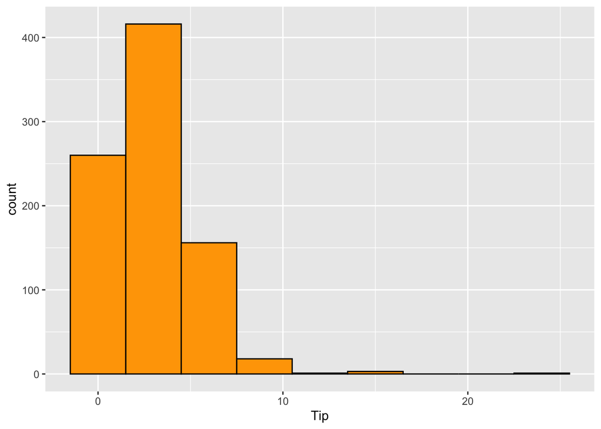

```r
uber_trips_clean %>%
  filter(!is.na(Tip)) %>%
  ggplot(aes(x = Tip)) +
  geom_histogram(binwidth = 3, fill="orange", colour="black")
```

‘Tip’ variable represent a right-skewed unimodal distribution with several extreme outliers (more than 3 standard deviations from the mean).

### Find dyas when tips received most frequently

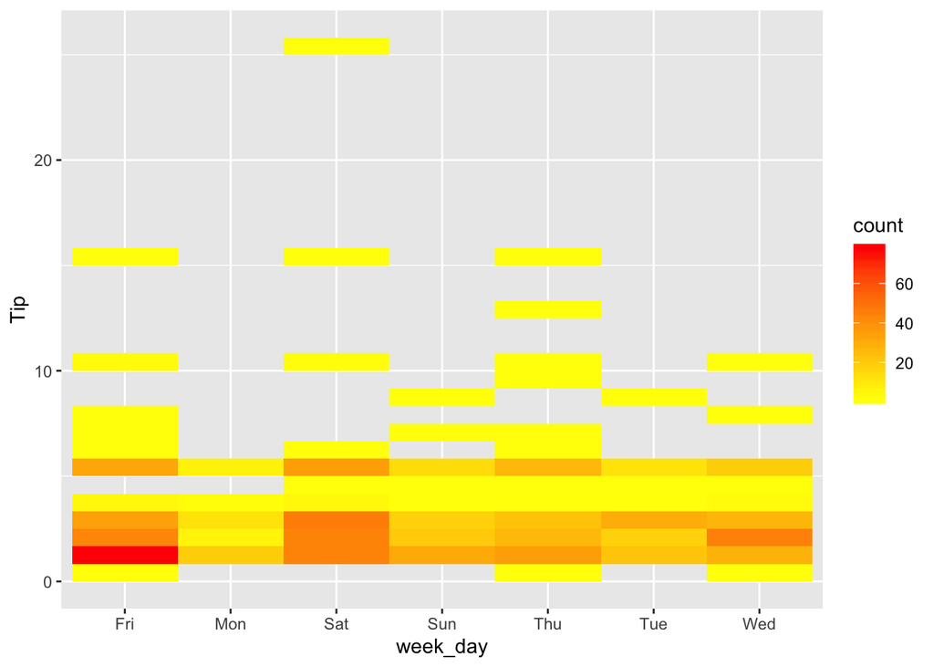

```r
# Build a frequency plot
uber_trips_clean %>%
  filter(!is.na(Tip)) %>%
  ggplot(aes(y = Tip, x = week_day)) +
  geom_bin2d() +
  scale_fill_gradient(low = "yellow", high="red")
```

```r
# Number of trips with tip and trips per week day
days_stat <- uber_trips_clean %>%
  filter(is.na(Cancellation)) %>%
  group_by(week_day) %>%
  summarise(trips_w_tip = sum(!is.na(Tip)), trips_total = n(), tip_frequency = trips_w_tip/trips_total)

days_stat
```

```
## # A tibble: 7 x 4
##   week_day trips_w_tip trips_total tip_frequency
##   <chr>          <int>       <int>         <dbl>
## 1 Fri              202         652         0.310
## 2 Mon               47         189         0.249
## 3 Sat              182         636         0.286
## 4 Sun               88         365         0.241
## 5 Thu              119         394         0.302
## 6 Tue               87         279         0.312
## 7 Wed              130         456         0.285
```

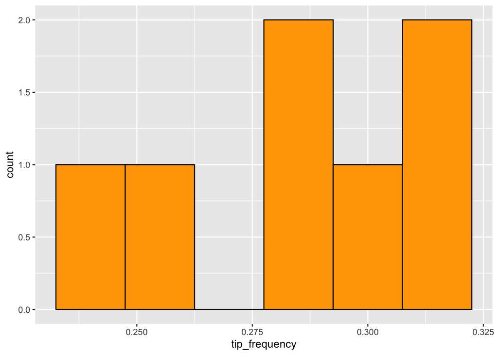

```r
# Tip frequency histogram
days_stat %>%
  ggplot(aes(x = tip_frequency)) +
  geom_histogram(binwidth = 0.015, fill="orange", colour="black")
```

## ANOVA hypothesis test

From the statistics above, we can see that Tuesdays, Fridays, and Thursdays are the days when riders tip most often (close to 30% of all trips are tipped). However, tip frequency for all week days is quite close.

It’s interesting to check whether the differencies in frequencies are due to chance or not. We’ll be using ANOVA test to find out.

### Set up hypothesis

H0: Average tip frequency is the same around the week  
HA: Average tip frequency differs at least on one day

Significance level (α) = 0.05

### Prepare data

All of the observations in our data represent separate rides. To be able to analyze certain days as observations, we need to make some tweaks:

```r
# we create a new variable shift_date which differs from the actual date if the trip done after midnight but before 5am (explained earlier)
uber_trips_clean <- uber_trips_clean %>%
  mutate(shift_date = ifelse(hour(date_time) > 5, as.character(date(date_time)), as.character(date(date_time) - 1)))

# combine week day name and shift date to create
uber_trips_clean$shift <- paste(uber_trips_clean$week_day, uber_trips_clean$shift_date)

# create a separate data frame with shifts observations. Filter for cancelled trips (see above)
uber_shifts <- uber_trips_clean %>%
  filter(is.na(Cancellation)) %>%
  group_by(shift) %>%
  summarise(weekday = first(week_day), trips_w_tip = sum(!is.na(Tip)), trips_total = n(), tip_frequency = trips_w_tip/trips_total)
```

### Check summary statistics

We need to check the form of tip frequency distribution, mean, and variability.

```r
# summary statistics table
uber_shifts %>%
  summarise(days_total = n(), frequency_mean = mean(tip_frequency), frequency_sd = sd(tip_frequency))
```

```
## # A tibble: 1 x 3
##   days_total frequency_mean frequency_sd
##        <int>          <dbl>        <dbl>
## 1        245          0.288        0.157
```

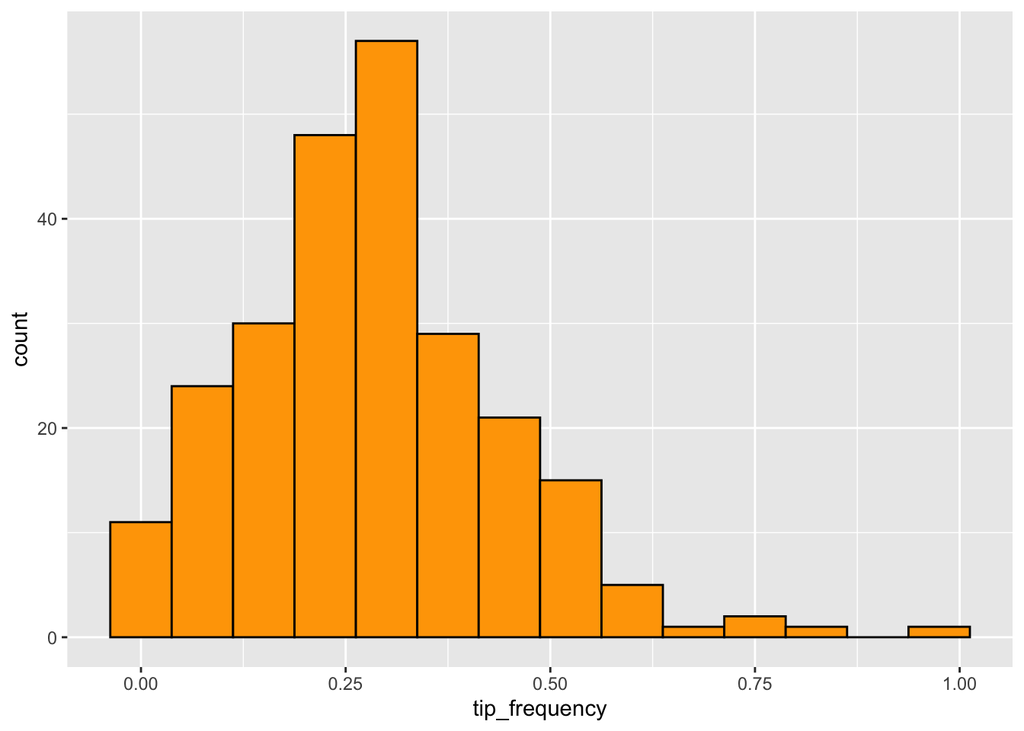

```r
# build a histogram for tip frequency
uber_shifts %>%
  ggplot(aes(x = tip_frequency)) +
  geom_histogram(binwidth = 0.075, fill="orange", colour="black")
```

The histogram above shows a slight right skew. There are extreme outliers (over 3 sd’s from the mean).

Summary statistics grouped by week days:

```r
# calculate variability within the groups
uber_shifts_summary <- uber_shifts %>%
  group_by(weekday) %>%
  summarise(wday_size = n(), wday_mean = mean(tip_frequency), wday_sd = sd(tip_frequency))

uber_shifts_summary
```

```
## # A tibble: 7 x 4
##   weekday wday_size wday_mean wday_sd
##   <chr>       <int>     <dbl>   <dbl>
## 1 Fri            44     0.310   0.115
## 2 Mon            19     0.242   0.141
## 3 Sat            41     0.289   0.146
## 4 Sun            31     0.239   0.142
## 5 Thu            37     0.304   0.196
## 6 Tue            29     0.304   0.188
## 7 Wed            44     0.293   0.160
```

### Check conditions - ANOVA graphical diagnostics

#### Independence

Considering the fact that we analyze data for one driver only, it’s unclear if daily observations are independent of each other. In case of consequitive days (Thursday, Friday, Saturday, etc.), there’s a good chance that they are not independent in terms of driver’s behavior, car condition and other factors that influence tipping. However, for example, two Fridays of different weeks (even if consequitive) and months are most likely to be independent. There are not obvious reasons why independence would not hold for most or all observations.

#### Normality

The normality assumption is especially important when the sample size is quite small. The normal probability plots for each week day are shown below:

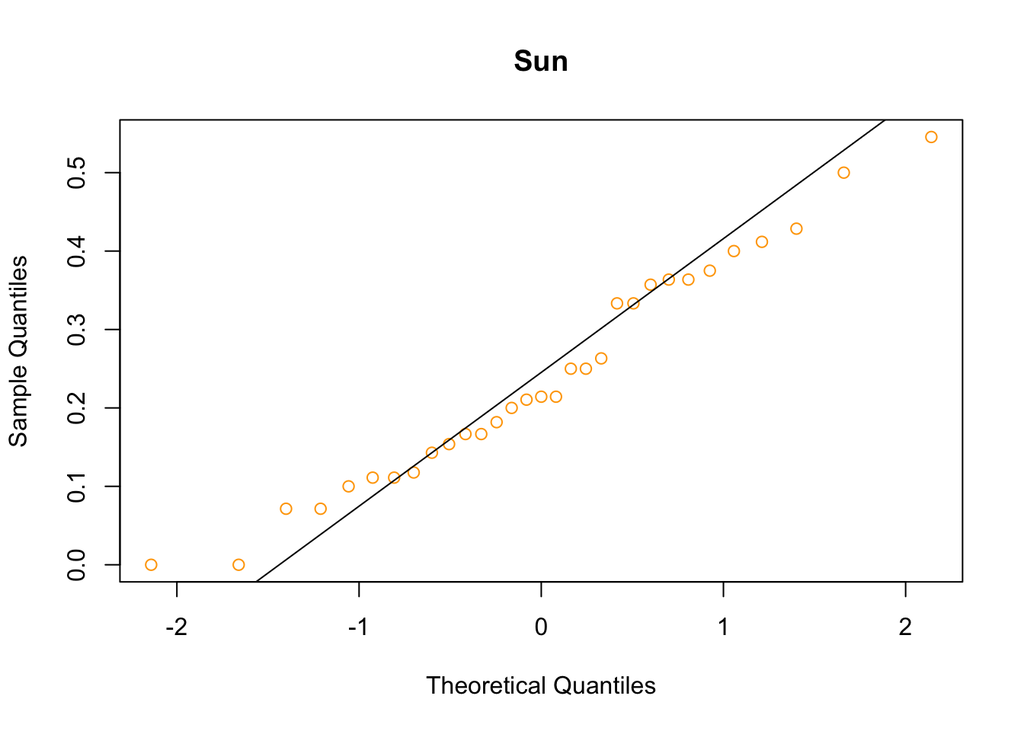

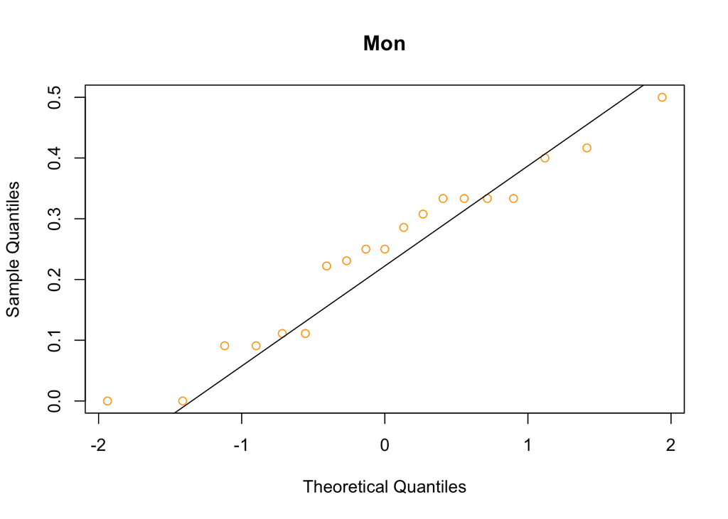

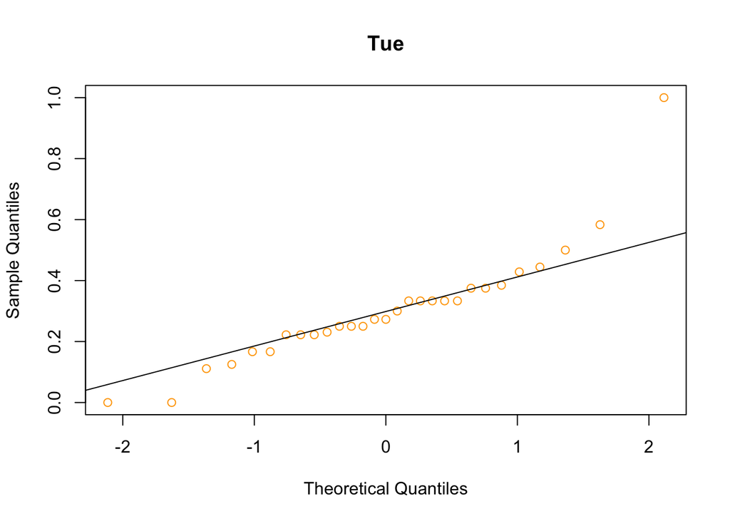

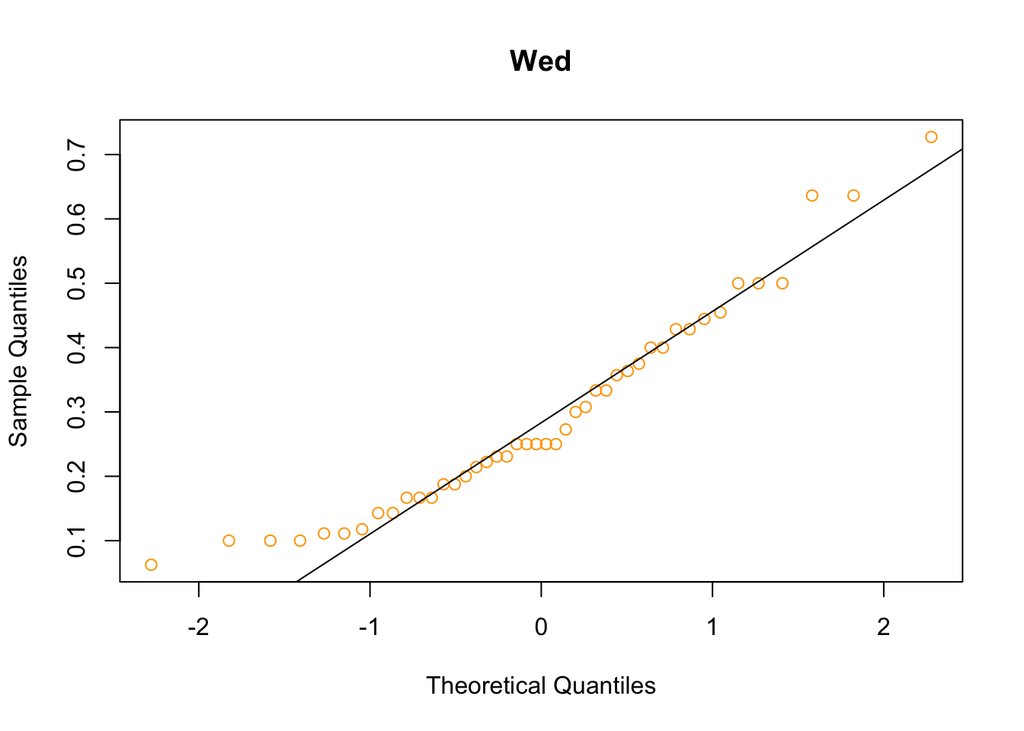

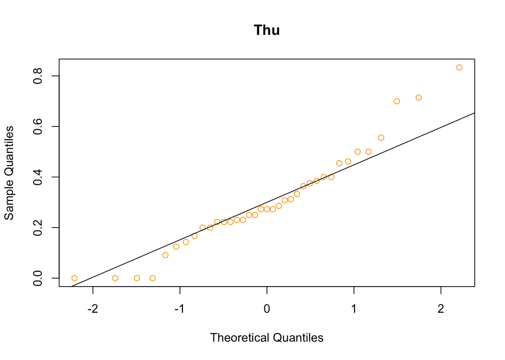

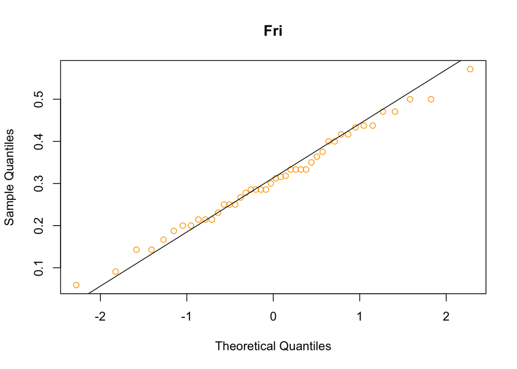

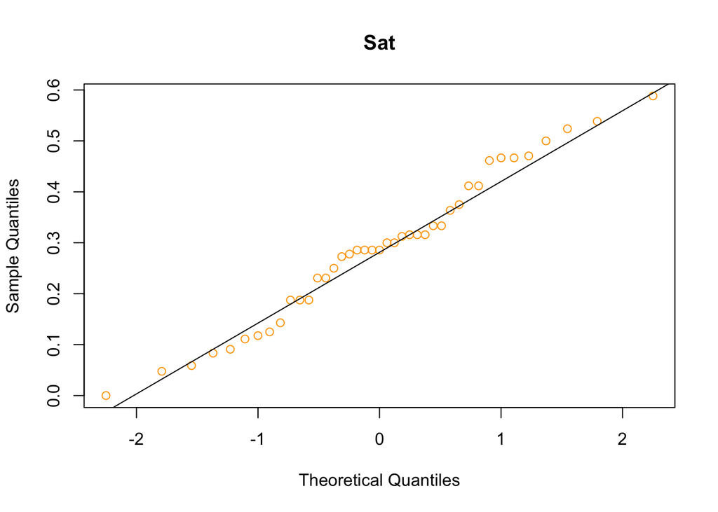

```r
# build the normal probability plots for all seven groups
for (i in c("Sun", "Mon", "Tue", "Wed", "Thu", "Fri", "Sat")) {
uber_shifts_days <- uber_shifts %>%
  filter(weekday == i)
qqnorm(uber_shifts_days$tip_frequency, main = i, col="orange")
qqline(uber_shifts_days$tip_frequency)
}
```

- Sun - points follow an S-shaped curve which indicates short tails (narrower than the normal distribution)
- Mon - not clear
- Tue - points start below the line, bend to follow it, and end above it which indicates long tails (wider than the normal distribution)
- Wed - points bend up and to the left of the line - obviously, right skew
- Thu - not clear
- Fri - nearly normal
- Sat - nearly normal

There are some deviation from normality for most of the week days except Friday and Saturday. The sample sizes are not large. The outliers are not extreme, though. The normality of the distributions can be a concern in this case.

#### Constant variance

The last assumption is that the variance in the groups is about equal from one group to the next. This assumption can be checked by examining a side-by-side box plot of the tipping frequency across the week days.

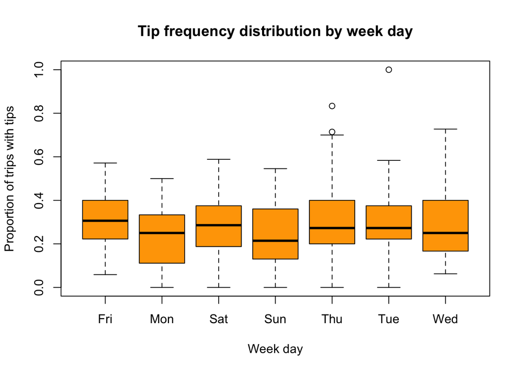

```r
boxplot(uber_shifts$tip_frequency ~ uber_shifts$weekday, col="orange",  main = "Tip frequency distribution by week day", ylab = "Proportion of trips with tips", xlab = "Week day")
```

In this case, the variability is **similar in the 7 groups but not identical**. We saw in a previous section that the standard deviation varies a bit from one group to the next. Whether these differences are from natural variation is unclear.

*We’ve checked the outlier for Tuesday when proportion of trips with tips was 1. Indeed, on August 20, 2019, driver made 7 trips and received tips for each of them.*

### Compute one-way ANOVA test

Now, we want to calculate the test results. We can use the F statistic to evaluate the hypotheses in what is called an F test.

Analysis of variance (ANOVA) is used to test whether the mean outcome differs across 2 or more groups. The test statistic F represents a standardized ratio of variability in the sample means relative to the variability within the groups. If H0 is true and the model assumptions are satisfied, the statistic F follows an F distribution with parameters df1 = k - 1 and df2 = n - k. The upper tail of the F distribution is used to represent the p-value.

```r
# Compute the analysis of variance
results_aov <- aov(tip_frequency ~ weekday, data = uber_shifts)

# Summary of the analysis
summary(results_aov)
```

```
##              Df Sum Sq Mean Sq F value Pr(>F)
## weekday       6  0.154 0.02558   1.042  0.399
## Residuals   238  5.846 0.02456
```

The calculated p-value is 0.399, which is, obviously, larger than 0.05, indicating the evidence is not strong enough to reject the null hypothesis at a significance level of 0.05. That is, **the data do not provide strong evidence that the average tip frequency varies by week day.** The variance we saw could be due to chance.

As our analysis didn’t show the difference between the groups, we would not proceed with the group to group comparison.

### Check ANOVA assumptions with other methods

*The following tests have been adopted from the article on STHDA (http://www.sthda.com/english/wiki/one-way-anova-test-in-r).

The ANOVA test assumes that, the data are normally distributed and the variance across groups are homogeneous. We can check that with some diagnostic plots.

#### Homogenity of variance

The residuals versus fits plot can be used to check the **homogeneity of variances**.

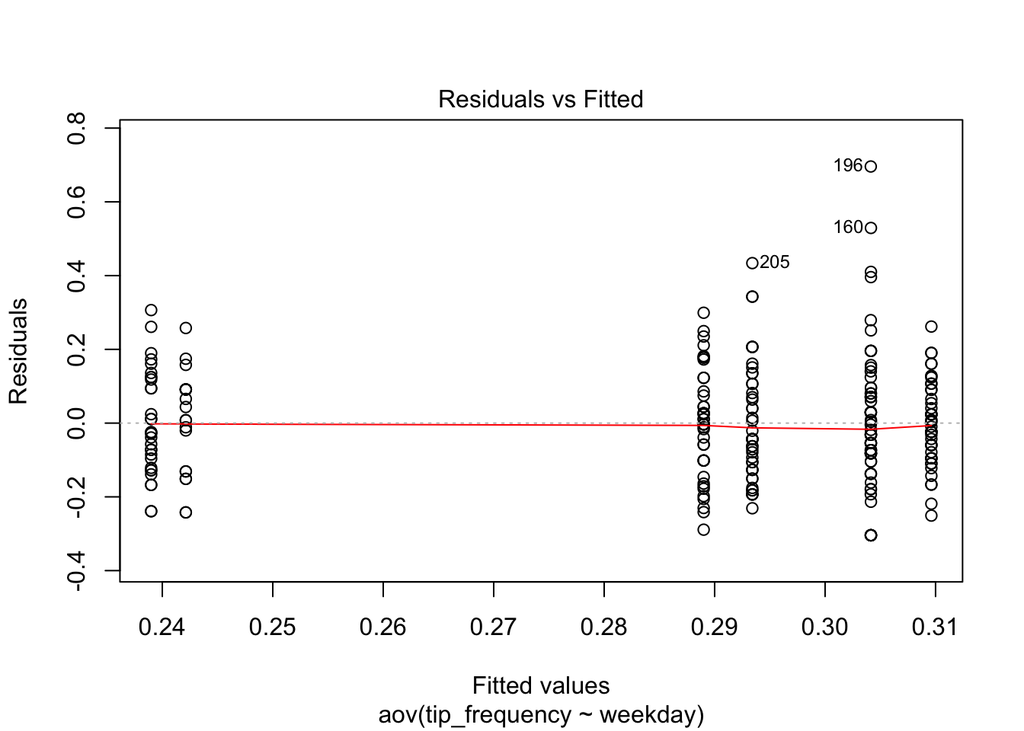

```r
# Homogeneity of variances
plot(results_aov, 1)
```

*I’m not sure how to interpret this plot and need to get back to it once I learn more* However, it looks pretty similar to one in the article. It could mean that there is no evident relationships between residuals and fitted values (the mean of each groups), which is good. So, we can assume the homogeneity of variances.

It’s also possible to use **Levene’s test** to check the homogeneity of variances.

```r
leveneTest(tip_frequency ~ weekday, center=median, data = uber_shifts)
```

```
## Levene's Test for Homogeneity of Variance (center = median)
##        Df F value Pr(>F)
## group   6  0.9306 0.4736
##       238
```

From the output above we can see that the p-value is not less than the significance level of 0.05. This means that there is no evidence to suggest that the variance across groups is statistically significantly different. Therefore, we can assume the homogeneity of variances in the different treatment groups.

The Levene’s test is not significant. The homogeneity is fine.

#### Normality

Normality plot of residuals. In the plot below, the quantiles of the residuals are plotted against the quantiles of the normal distribution. A 45-degree reference line is also plotted.

The normal probability plot of residuals is used to check the assumption that the residuals are normally distributed. It should approximately follow a straight line.

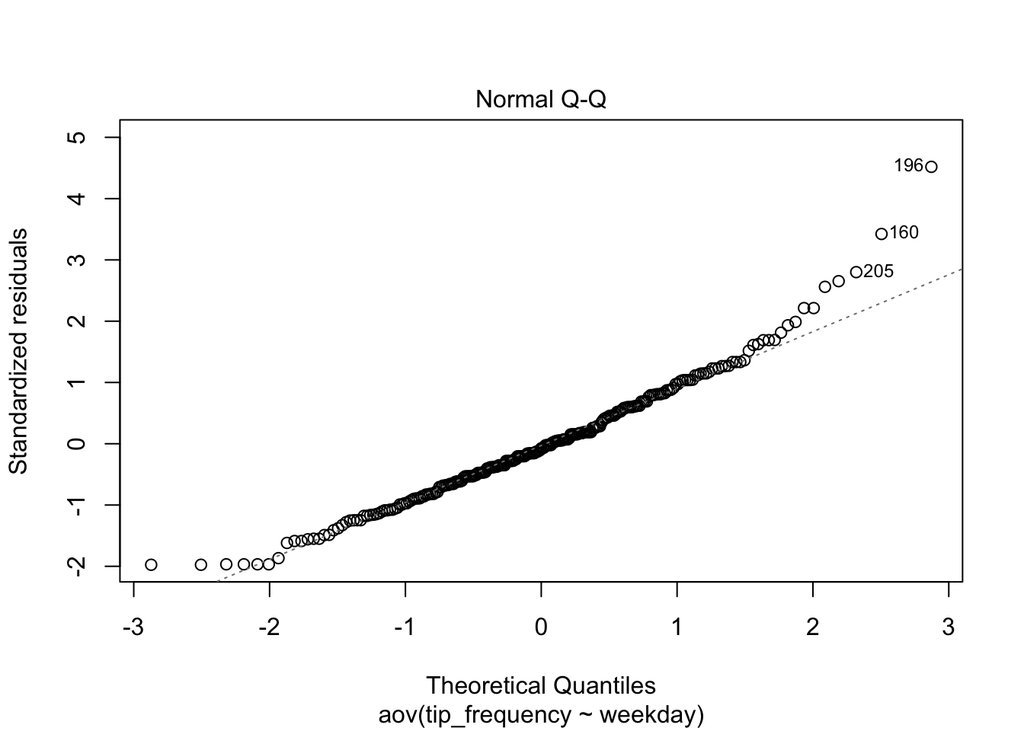

```r
# Normality
plot(results_aov, 2)
```

In fact, we see the signs of a right skew here (points bend up and to the left of the line). As the distribution is not perfectly normal, it would be handy to run a **Shapiro-Wilk test** on the ANOVA residuals.

```r
# Extract the residuals
aov_residuals <- residuals(object = results_aov )
# Run Shapiro-Wilk test
shapiro.test(x = aov_residuals )
```

```
##
##  Shapiro-Wilk normality test
##
## data:  aov_residuals
## W = 0.97232, p-value = 0.000104
```

The p-value is lower than 0.05 significance level, which means that there’s less than 1% chance of seeing this distribution if it was in fact normal. Thus, *the normality assumption is not satisfied.*

### Non-parametric alternative to one-way ANOVA test

There are concerns about normality in our analysis. We can try using a non-parametric alternative to a one-way ANOVA - **Kruskal-Wallis** rank sum test, which can be used when ANOVA assumptions are not met.

```r
kruskal.test(tip_frequency ~ weekday, data = uber_shifts)
```

```
##
##  Kruskal-Wallis rank sum test
##
## data:  tip_frequency by weekday
## Kruskal-Wallis chi-squared = 6.1435, df = 6, p-value = 0.4073
```

Employing a Kruskal-Wallis test, we’ve got a p-value of 0.4073, which is significantly larger than 0.05, meaning that there’s not enough evidence to reject the null hypothesis. This result is very close to the p-value from the ANOVA test (0.399).

### Conclusion for the tip frequency analysis

We run ANOVA and Kruskal-Wallis tests to check the hypothesis that UBER riders tip more often on certain days of the week. Neither test could provide significant evidence to reject the null hypothesis at 5% significance level.

There are concerns that should be mentioned. First, the normality of the distribution. Second, the sample size for some of the groups (for example, we only have data for 19 Mondays).

# Fare Level problem

In National Tipping Field Experiment, Chandar, et al. (2019) report that “riders are more likely to tip as the fare of the trip increses, but at a decreasing rate.”

**Does our data aligns with this statement? Is there an association between the fare level and tip size?**

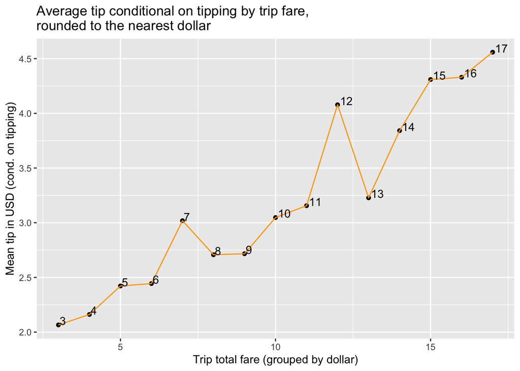

```r
uber_trips_clean %>%
  filter(is.na(Cancellation)) %>% #filtering for cancelled trips
  mutate(Tip =  ifelse(is.na(Tip), 0, Tip)) %>%
  mutate(Total = round(Total-Tip)) %>% #deducting total by tip amount, rounding total to nearest dollar
  filter(Tip > 0, Total >= 2) %>% #filtering for trips that were not tipped, and for those with a total less than $2 (those are probably just adjastments for previous trips and not the actual rides as the minimal fare for any trip is between $2 and $3)
  group_by(Total) %>% #creating bins for different amounts of total fare
  filter(n() > 9) %>% #filtering for bins with less than 10 trips inside
  summarize(mean_tip = mean(Tip)) %>%
  ggplot(aes(x = Total, y = mean_tip)) +
  geom_point() +
  geom_line(col = "orange") +
  geom_text(aes(label= Total), hjust = -0.2, vjust = 0) +
  labs(title = "Average tip conditional on tipping by trip fare, \nrounded to the nearest dollar", y = "Mean tip in USD (cond. on tipping)", x = "Trip total fare (grouped by dollar)")
```

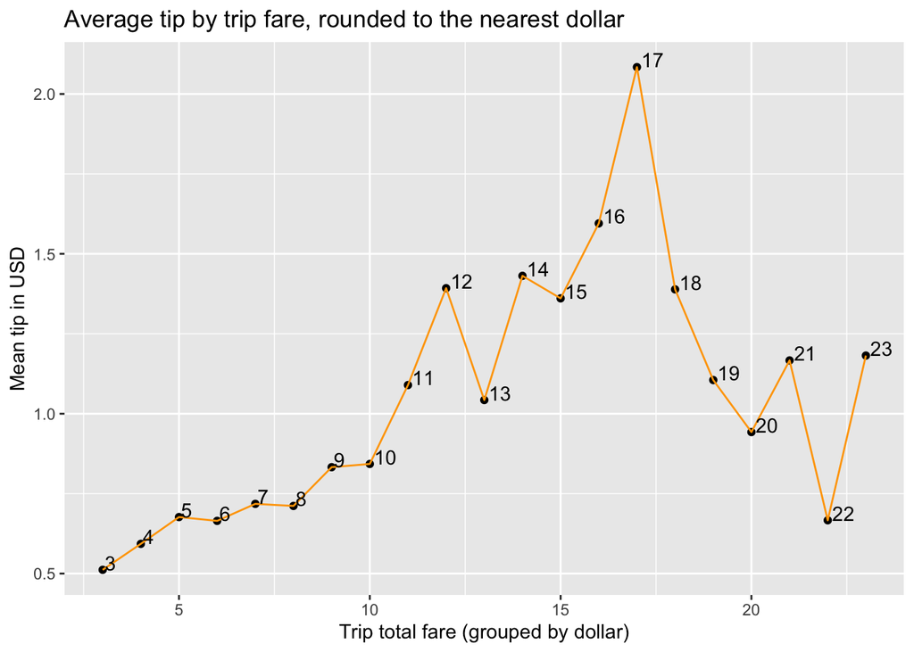

```r
uber_trips_clean %>%
  filter(is.na(Cancellation)) %>% #see previous code chunk for explanations
  mutate(Tip =  ifelse(is.na(Tip), 0, Tip)) %>% #replacing all NAs with 0
  mutate(Total = round(Total-Tip)) %>% #deducting tips from total
  filter(Total >= 2) %>% #filtering for trips with total fare less than $2
  group_by(Total) %>%
  filter(n() > 9) %>%
  summarize(mean_tip = mean(Tip)) %>%
  ggplot(aes(x = Total, y = mean_tip)) +
  geom_point() +
  geom_line(col = "orange") +
  geom_text(aes(label= Total), hjust = -0.2, vjust = 0) +
  labs(title = "Average tip by trip fare, rounded to the nearest dollar", y = "Mean tip in USD", x = "Trip total fare (grouped by dollar)")
```

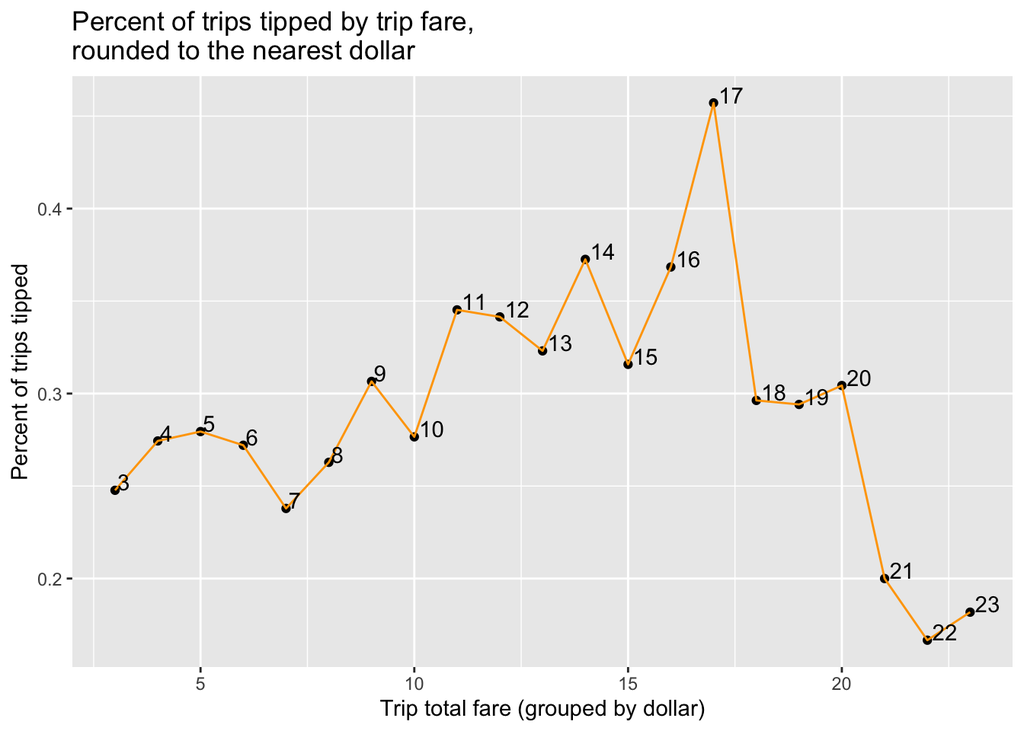

```r
uber_trips_clean %>%
  mutate(Tip =  ifelse(is.na(Tip), 0, Tip), Total = round(Total-Tip)) %>%
  filter(is.na(Cancellation), Total > 2) %>%
  group_by(Total) %>%
  filter(n() > 9) %>%
  summarize(trips_w_tips = sum(Tip>0), total_trips = n(), tips_frequency = trips_w_tips/n()) %>%
  ggplot(aes(x = Total, y = tips_frequency)) +
  geom_point() +
  geom_line(col = "orange") +
  geom_text(aes(label= Total), hjust = -0.2, vjust = 0) +
  labs(title = "Percent of trips tipped by trip fare, \nrounded to the nearest dollar", y = "Percent of trips tipped", x = "Trip total fare (grouped by dollar)")
```

If we had to build the confidence intervals for each of total fare bins, we had to exclude most of the bins that don’t meet 10 success/failures condition. On average, we have success rate between 25% and 30%. So, only bins with over 40 and over 30 trips respectively would potentially fit this condition.

# Machine Learning modeling

## Linear regression model

```r
uberML <- uber_trips_clean %>%
  mutate(Tip =  ifelse(is.na(Tip), 0, Tip)) %>%
  # Tip and Total variable are highly correlated because Total includes Tip. So we want to avoid this correlation for our models by creating a Total_minus_tip variable
  mutate(Total_minus_tip = (Total-Tip)) %>%
  mutate(date = format(date_time, '%Y-%m-%d'), trip_start = format(date_time, '%H:%M:%S'), tipped = ifelse(Tip==0, 0, 1)) %>%
  filter(is.na(Cancellation)) %>%
  select(7:33) %>%
  select(tipped, Tip, date, week_day, Total_minus_tip, trip_start, everything()) %>%
  select(1:24)


uberLM <- lm(Tip ~ Total_minus_tip, data=uberML)

summary(uberLM)
```

```
##
## Call:
## lm(formula = Tip ~ Total_minus_tip, data = uberML)
##
## Residuals:
##     Min      1Q  Median      3Q     Max
## -2.8988 -0.7940 -0.5491  0.3566 23.8280
##
## Coefficients:
##                 Estimate Std. Error t value Pr(>|t|)
## (Intercept)     0.311129   0.049476   6.288 3.68e-10 ***
## Total_minus_tip 0.070393   0.005688  12.376  < 2e-16 ***
## ---
## Signif. codes:  0 '***' 0.001 '**' 0.01 '*' 0.05 '.' 0.1 ' ' 1
##
## Residual standard error: 1.636 on 2969 degrees of freedom
## Multiple R-squared:  0.04906,    Adjusted R-squared:  0.04874
## F-statistic: 153.2 on 1 and 2969 DF,  p-value: < 2.2e-16
```

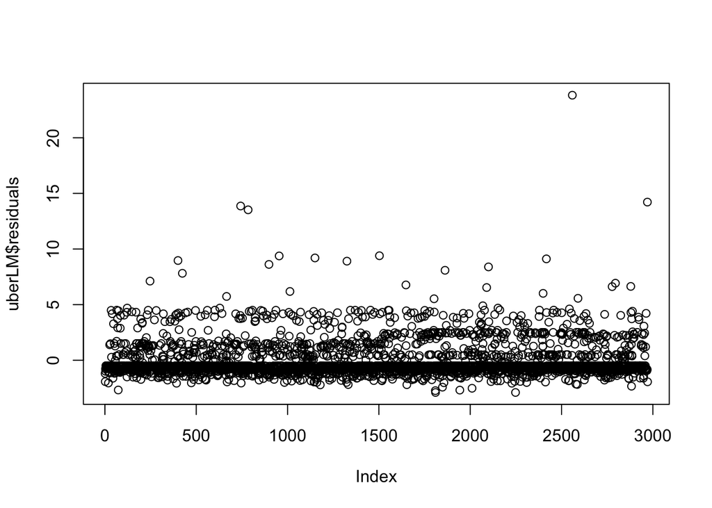

```r
plot(uberLM$residuals)
```

Residuals distribution looks pretty random, which is good.

Let’s try adding other variables to the model.

```r
uberLM_ <- lm(Tip ~ Total_minus_tip + Distance + Time, data=uberML)

summary(uberLM_)
```

```
##
## Call:
## lm(formula = Tip ~ Total_minus_tip + Distance + Time, data = uberML)
##
## Residuals:
##     Min      1Q  Median      3Q     Max
## -3.2274 -0.7998 -0.4987  0.2914 23.8726
##
## Coefficients:
##                 Estimate Std. Error t value Pr(>|t|)
## (Intercept)      0.12316    0.06401   1.924   0.0544 .
## Total_minus_tip  0.09495    0.01645   5.772 8.66e-09 ***
## Distance        -0.06664    0.02438  -2.734   0.0063 **
## Time             0.16882    0.06735   2.507   0.0122 *
## ---
## Signif. codes:  0 '***' 0.001 '**' 0.01 '*' 0.05 '.' 0.1 ' ' 1
##
## Residual standard error: 1.627 on 2921 degrees of freedom
##   (46 observations deleted due to missingness)
## Multiple R-squared:  0.06052,    Adjusted R-squared:  0.05955
## F-statistic: 62.72 on 3 and 2921 DF,  p-value: < 2.2e-16
```

## Logistic regression

The code below estimates a **logistic regression model** using the glm (generalized linear model) function. Logistic regression wors for any binary response variable. First, we convert `tipped` to a factor to indicate that `rank`tipped` variable should be treated as a categorical variable.

```r
uberML[,1] = as.factor(uberML[,1])

tippedLogitM <- glm(tipped ~ Total_minus_tip + Distance + Time + week_day, data = uberML, family = 'binomial')

summary(tippedLogitM)
```

```
##
## Call:
## glm(formula = tipped ~ Total_minus_tip + Distance + Time + week_day,
##     family = "binomial", data = uberML)
##
## Deviance Residuals:
##     Min       1Q   Median       3Q      Max
## -1.3049  -0.8246  -0.7660   1.4502   1.8708
##
## Coefficients:
##                 Estimate Std. Error z value Pr(>|z|)
## (Intercept)     -1.16720    0.11698  -9.978  < 2e-16 ***
## Total_minus_tip  0.03811    0.02181   1.747  0.08058 .
## Distance        -0.04601    0.03263  -1.410  0.15852
## Time             0.15864    0.09038   1.755  0.07920 .
## week_dayMon     -0.24762    0.19169  -1.292  0.19643
## week_daySat     -0.16441    0.12578  -1.307  0.19115
## week_daySun     -0.51006    0.15854  -3.217  0.00129 **
## week_dayThu     -0.03786    0.14076  -0.269  0.78796
## week_dayTue      0.06346    0.15612   0.406  0.68439
## week_dayWed     -0.09111    0.13605  -0.670  0.50307
## ---
## Signif. codes:  0 '***' 0.001 '**' 0.01 '*' 0.05 '.' 0.1 ' ' 1
##
## (Dispersion parameter for binomial family taken to be 1)
##
##     Null deviance: 3461.2  on 2924  degrees of freedom
## Residual deviance: 3425.3  on 2915  degrees of freedom
##   (46 observations deleted due to missingness)
## AIC: 3445.3
##
## Number of Fisher Scoring iterations: 4
```

Not impressive by any means. The only parameter that is statistically significant at 5% alpha is `week_daySun`, at 10% alpha - both `Total_minus_tip` and `Time` are statistically significant. The logistic regression coefficients give the change in the log odds of the outcome for a one unit increase in the predictor variable.

- For every one unit change in `Time` (measured in $ here), the log odds of being tipped (versus non-tipped) increases by 0.159.
- The indicator variables for `week_day` have a slightly different interpretation. For example, making Sunday trip, versus Friday trip, changes the log odds of receiving a tip by -0.51.

We can use the confint function to obtain confidence intervals for the coefficient estimates. Note that for logistic models, confidence intervals are based on the profiled log-likelihood function.

```r
confint(tippedLogitM)
```

```
##                        2.5 %      97.5 %
## (Intercept)     -1.398259182 -0.93946899
## Total_minus_tip -0.004913197  0.08097202
## Distance        -0.110123189  0.01794849
## Time            -0.018749012  0.33586885
## week_dayMon     -0.631034468  0.12178051
## week_daySat     -0.411438308  0.08183965
## week_daySun     -0.825212488 -0.20304297
## week_dayThu     -0.315220448  0.23691058
## week_dayTue     -0.244992998  0.36752898
## week_dayWed     -0.358974514  0.17466072
```

Clearly, the confidence intervals show that the reliability of our coefficinets isn’t high (except for Sunday trips). For example, real `Time` coefficient can be anywhere between -0.019 and 0.34. In other words, each eaxtra dollar in `Time` amount could either decrease or increase the chances of getting a tip. Not very useful. The Sunday trips are clearly decrease the chances of receiving a tip as both borders of the interval are below zero.

We can try using a 90% confidence interval instead to get more reliable values for `Total_minus_tip` and `Time` variables (`Distance` still won’t be significant at 90%, though).

```r
confint(tippedLogitM, level = 0.9)
```

```
##                          5 %         95 %
## (Intercept)     -1.360856917 -0.975886668
## Total_minus_tip  0.002065298  0.074048738
## Distance        -0.099787465  0.007655336
## Time             0.009825459  0.307342585
## week_dayMon     -0.568262051  0.063165921
## week_daySat     -0.371642063  0.042271011
## week_daySun     -0.773906164 -0.251939986
## week_dayThu     -0.270408388  0.192866519
## week_dayTue     -0.195037051  0.318873122
## week_dayWed     -0.315727989  0.132034374
```

We can also exponentiate the coefficients and interpret them as **odds-ratios**.

```r
## odds ratios and 90% CI
exp(cbind(OddsRatios = coef(tippedLogitM), confint(tippedLogitM, level = 0.9)))
```

```
##                 OddsRatios       5 %      95 %
## (Intercept)      0.3112377 0.2564409 0.3768581
## Total_minus_tip  1.0388487 1.0020674 1.0768593
## Distance         0.9550290 0.9050297 1.0076847
## Time             1.1719168 1.0098739 1.3598067
## week_dayMon      0.7806570 0.5665091 1.0652036
## week_daySat      0.8483902 0.6896010 1.0431772
## week_daySun      0.6004579 0.4612080 0.7772914
## week_dayThu      0.9628489 0.7630678 1.2127209
## week_dayTue      1.0655176 0.8228042 1.3755768
## week_dayWed      0.9129173 0.7292578 1.1411475
```

Here, instead of log odds we get the ‘normal’ odds like 4 to 1 or 1 to 1. So we can say for a one dollar increase in `Time` earnings, we expect to see about 17% increase in the odds of being tipped (odds are 1.17 to 1). This 17% of increase does not depend on the value that `Time` is held at.

## ML modeling with H2O.ai engine

Save dataframe as h2o object and split for training and testing datasets. We don’t creat a validation part here as our data set is quite small and we want to feed more data to the training model.

```r
uberML_h2o <- as.h2o(uberML)
uberML_h2o[,1] = as.factor(uberML_h2o[,1])
uberML_h2o[,4] = as.factor(uberML_h2o[,4])
parts1 <- h2o.splitFrame(uberML_h2o, 0.8)
train1 <- parts1[[1]]
test1 <- parts1[[2]]
```

We will be using this great tool from the h2o package called **AutoML**. It, basically, tries applying different models to our data including gradient boosting, generalized linear model, deep learning and many more.

First, we are going to predict the tip amount (`Tip`). This is a numerical variable, so no classification methods would be applied.

AutoML then provides the leaderboard with models and their performances:

```r
aML_leaders <- aML@leaderboard
print(aML_leaders, n = nrow(aML_leaders))
```

```
##                                               model_id mean_residual_deviance
## 1                         GLM_1_AutoML_20200128_145731               2.767581
## 2                DeepLearning_1_AutoML_20200128_145731               2.784562
## 3  StackedEnsemble_BestOfFamily_AutoML_20200128_145731               2.786541
## 4     StackedEnsemble_AllModels_AutoML_20200128_145731               2.793330
## 5                         GBM_5_AutoML_20200128_145731               2.797440
## 6                     XGBoost_3_AutoML_20200128_145731               2.819883
## 7       XGBoost_grid__1_AutoML_20200128_145731_model_1               2.820440
## 8                         XRT_1_AutoML_20200128_145731               2.821129
## 9                         DRF_1_AutoML_20200128_145731               2.831400
## 10                        GBM_3_AutoML_20200128_145731               2.898498
## 11                        GBM_2_AutoML_20200128_145731               2.898834
## 12                    XGBoost_2_AutoML_20200128_145731               2.899285
## 13                    XGBoost_1_AutoML_20200128_145731               2.945770
## 14                        GBM_1_AutoML_20200128_145731               2.973103
```

[output cut: 19 more lines]

```r
aML_leader1 <- aML@leader
perf <- h2o.performance(aML_leader1, test1)
perf
```

```
## H2ORegressionMetrics: glm
##
## MSE:  2.352762
## RMSE:  1.533872
## MAE:  1.081666
## RMSLE:  0.6272792
## Mean Residual Deviance :  2.352762
## R^2 :  0.05421924
## Null Deviance :1556.474
## Null D.o.F. :623
## Residual Deviance :1468.124
## Residual D.o.F. :612
## AIC :2330.724
```

No surprise, the best performing model for the split is GLM (Generalized Linear Model). AutoML doesn’t show us the adjusted R^2 value for the model for us to directly compare it to the linear regression model we had before. However, *NOTE: Chances are high that a leading algorithm would be different for a different split.*

If the leading model is GLM, we can check coefficients for the actual model:

```r
#h2o.coef(aML_leader1)
```

We can now try applying AutoML to the variable `tipped` which has only 2 categories 0 and 1 (not tipped and tipped).

```r
tipped_aML_leaders <- tipped_aML@leaderboard
print(tipped_aML_leaders, n = nrow(tipped_aML_leaders))
```

```
##                                               model_id       auc   logloss
## 1                         GLM_1_AutoML_20200128_145814 0.5540270 0.6010820
## 2                         GBM_1_AutoML_20200128_145814 0.5430227 0.5960138
## 3                         DRF_1_AutoML_20200128_145814 0.5412857 0.6392399
## 4                         GBM_4_AutoML_20200128_145814 0.5357000 0.6108707
## 5  StackedEnsemble_BestOfFamily_AutoML_20200128_145814 0.5328226 0.5927069
## 6     StackedEnsemble_AllModels_AutoML_20200128_145814 0.5328226 0.5927069
## 7                     XGBoost_3_AutoML_20200128_145814 0.5291765 0.5935797
## 8                         GBM_3_AutoML_20200128_145814 0.5283159 0.6074595
## 9                     XGBoost_2_AutoML_20200128_145814 0.5208059 0.6010135
## 10                        GBM_2_AutoML_20200128_145814 0.5190456 0.6052544
## 11                    XGBoost_1_AutoML_20200128_145814 0.5178408 0.6048522
##        aucpr mean_per_class_error      rmse       mse
## 1  0.3381157            0.4979665 0.4533552 0.2055309
## 2  0.3889703            0.4916917 0.4503917 0.2028527
## 3  0.3806007            0.4963093 0.4660077 0.2171632
## 4  0.3680843            0.4937497 0.4564339 0.2083319
## 5  0.3833789            0.4938001 0.4486984 0.2013302
## 6  0.3833789            0.4938001 0.4486984 0.2013302
## 7  0.3635173            0.4938001 0.4497225 0.2022504
## 8  0.3716088            0.4971133 0.4547983 0.2068415
## 9  0.3635273            0.4976653 0.4527421 0.2049754
## 10 0.3688319            0.4910130 0.4542838 0.2063738
## 11 0.3657791            0.4987448 0.4546143 0.2066742
##
## [11 rows x 7 columns]
```

```r
tipped_aML_leader1 <- tipped_aML@leader
h2o.performance(tipped_aML_leader1, test1)
```

```
## H2OBinomialMetrics: glm
##
## MSE:  0.1965315
## RMSE:  0.4433187
## LogLoss:  0.5819908
## Mean Per-Class Error:  0.4946742
## AUC:  0.5414709
## AUCPR:  0.3038069
## Gini:  0.08294173
## R^2:  0.001088221
## Residual Deviance:  726.3245
## AIC:  750.3245
##
## Confusion Matrix (vertical: actual; across: predicted) for F1-optimal threshold:
##         0   1    Error      Rate
## 0      13 443 0.971491  =443/456
## 1       3 165 0.017857    =3/168
## Totals 16 608 0.714744  =446/624
##
## Maximum Metrics: Maximum metrics at their respective thresholds
##                         metric threshold      value idx
## 1                       max f1  0.221578   0.425258 384
## 2                       max f2  0.193458   0.648148 399
## 3                 max f0point5  0.281575   0.334596 217
## 4                 max accuracy  0.452486   0.733974   1
## 5                max precision  0.460555   1.000000   0
## 6                   max recall  0.193458   1.000000 399
## 7              max specificity  0.460555   1.000000   0
## 8             max absolute_mcc  0.452486   0.093422   1
## 9   max min_per_class_accuracy  0.288839   0.535714 193
## 10 max mean_per_class_accuracy  0.281575   0.543546 217
## 11                     max tns  0.460555 456.000000   0
## 12                     max fns  0.460555 167.000000   0
## 13                     max fps  0.206633 456.000000 397
## 14                     max tps  0.193458 168.000000 399
## 15                     max tnr  0.460555   1.000000   0
## 16                     max fnr  0.460555   0.994048   0
## 17                     max fpr  0.206633   1.000000 397
## 18                     max tpr  0.193458   1.000000 399
##
## Gains/Lift Table: Extract with `h2o.gainsLift(<model>, <data>)` or `h2o.gainsLift(<model>, valid=<T/F>, xval=<T/F>)`
```

Let’s split the data in 3 parts first.

```r
partsXGB <- h2o.splitFrame(uberML_h2o, ratios = c(0.6, 0.2))
trainXGB <- partsXGB[[1]]
validXGB <- partsXGB[[2]]
testXGB <- partsXGB[[3]]
```

```r
tippedXGB <- h2o.xgboost(4:14, 1,
                         training_frame = trainXGB,
                         validation_frame = validXGB,
                         model_id = 'tippedXGB',
                         stopping_rounds = 3, # stops if not improved for x number of last trees
                         stopping_metric = 'mean_per_class_error',
                         seed = 1234,
                         ntrees = 100,
                         max_depth = 200,
                         sample_rate = 0.69, ## use a random % of the rows to fit each tree (like in random forest)
                         col_sample_rate = 0.6, ## use a random % of the columns

                         )
summary(tippedXGB)
```

```
## Model Details:
## ==============
##
## H2OBinomialModel: xgboost
## Model Key:  tippedXGB
## Model Summary:
##   number_of_trees
## 1               9
##
## H2OBinomialMetrics: xgboost
## ** Reported on training data. **
##
## MSE:  0.09730684
## RMSE:  0.3119404
## LogLoss:  0.3418862
## Mean Per-Class Error:  0.09557973
## AUC:  0.9686784
## AUCPR:  0.890761
## Gini:  0.9373568
## R^2:  0.5288697
##
## Confusion Matrix (vertical: actual; across: predicted) for F1-optimal threshold:
##           0   1    Error       Rate
## 0      1186  85 0.066876   =85/1271
## 1        65 458 0.124283    =65/523
## Totals 1251 543 0.083612  =150/1794
##
## Maximum Metrics: Maximum metrics at their respective thresholds
##                         metric threshold       value idx
## 1                       max f1  0.375680    0.859287 187
## 2                       max f2  0.288527    0.885806 230
## 3                 max f0point5  0.472872    0.902680 143
## 4                 max accuracy  0.427230    0.919732 165
## 5                max precision  0.926188    1.000000   0
## 6                   max recall  0.142720    1.000000 331
## 7              max specificity  0.926188    1.000000   0
## 8             max absolute_mcc  0.427230    0.801863 165
## 9   max min_per_class_accuracy  0.343130    0.895358 202
## 10 max mean_per_class_accuracy  0.375680    0.904420 187
## 11                     max tns  0.926188 1271.000000   0
```

[output cut: 112 more lines]

```
##             variable relative_importance scaled_importance percentage
## 1           Distance          400.477020          1.000000   0.223996
## 2               Time          397.852173          0.993446   0.222528
## 3    Total_minus_tip          381.115448          0.951654   0.213167
## 4      DiamondReward          127.125916          0.317436   0.071105
## 5  MinFareSupplement          118.879395          0.296844   0.066492
## 6           WaitTime          112.220421          0.280217   0.062768
## 7              Surge           68.437149          0.170889   0.038279
## 8       week_day.Fri           46.272224          0.115543   0.025881
## 9       week_day.Sat           38.273396          0.095570   0.021407
## 10      week_day.Wed           27.605930          0.068933   0.015441
## 11      week_day.Thu           25.908997          0.064695   0.014492
## 12      week_day.Tue           23.435371          0.058519   0.013108
## 13      week_day.Sun           11.479535          0.028665   0.006421
## 14      week_day.Mon            8.790125          0.021949   0.004917
```

```r
#h2o.performance(tippedXGB, validXGB)
h2o.performance(tippedXGB, testXGB)
```

```
## H2OBinomialMetrics: xgboost
##
## MSE:  0.2196988
## RMSE:  0.4687204
## LogLoss:  0.6362795
## Mean Per-Class Error:  0.4785374
## AUC:  0.5450897
## AUCPR:  0.2986258
## Gini:  0.09017932
## R^2:  -0.09331076
##
## Confusion Matrix (vertical: actual; across: predicted) for F1-optimal threshold:
##         0   1    Error      Rate
## 0      34 396 0.920930  =396/430
## 1       6 160 0.036145    =6/166
## Totals 40 556 0.674497  =402/596
##
## Maximum Metrics: Maximum metrics at their respective thresholds
##                         metric threshold      value idx
## 1                       max f1  0.102540   0.443213 375
## 2                       max f2  0.074575   0.664532 390
## 3                 max f0point5  0.285127   0.364188 212
## 4                 max accuracy  0.926188   0.733221   0
## 5                max precision  0.926188   1.000000   0
## 6                   max recall  0.074575   1.000000 390
## 7              max specificity  0.926188   1.000000   0
## 8             max absolute_mcc  0.926188   0.175457   0
## 9   max min_per_class_accuracy  0.290362   0.560241 209
## 10 max mean_per_class_accuracy  0.285127   0.565901 212
## 11                     max tns  0.926188 430.000000   0
## 12                     max fns  0.926188 159.000000   0
## 13                     max fps  0.058991 430.000000 399
## 14                     max tps  0.074575 166.000000 390
## 15                     max tnr  0.926188   1.000000   0
## 16                     max fnr  0.926188   0.957831   0
## 17                     max fpr  0.058991   1.000000 399
## 18                     max tpr  0.074575   1.000000 390
##
## Gains/Lift Table: Extract with `h2o.gainsLift(<model>, <data>)` or `h2o.gainsLift(<model>, valid=<T/F>, xval=<T/F>)`
```

### Conclusion DRAFT

It’s pretty clear that we cannot make predictions on the tipping size and/or frequency based on the data Uber provides to its drivers. That would be interesting to check if pick-up/drop-off location impacts tipping but we don’t have these data now. Also, we can try including time of the day in the model. There is a widespread belief that people tip more during the late night trips. We doubt this, but it would be interesting to find out.